# Workflow

16 October 2021

# 1 Introduction

This is a description of the workflow for *qaLabel*, which applies QA labels to each observation in a CyTOF dataset.

```r
library(qaLabel)
library(ggplot2)
```

# 2 Read in data and create initial datasets

The function read in the data and formats a that contains all of the QA variables. The variables are renamed so that their names can be easily accessed by downstream functions. The help file specifies how to do this. The Gaussian parameters and event length are transformed with the function. The output is a .

```r
fname <- "../../data/Sarah_data/U2OS_NT-1_GFP_Spike_NORMAL_01_1.fcs"
tech <- dataPrep(fname,
                 time = "Time",
                 beads = c("Beads"),
                 dna = c("DNA1", "DNA2"),
                 event_length = "Event_length",
                 viability = "Viability")
head(tech)
```

```
#>        Time     Bead1     DNA1     DNA2 Viability1 Viability2 Event_length
#> [1,]  6.719 0.1316999 6.251017 6.923103  0.1134849   6.099206     3.610918
#> [2,] 13.034 0.5906921 6.524184 7.130903  0.0000000   6.470780     3.637586
#> [3,] 13.685 1.2036122 6.198564 6.811621  0.0000000   5.159836     3.367296
#> [4,] 19.089 1.0924177 6.411788 6.986782  0.3198545   1.476082     3.688879
#> [5,] 25.768 0.3034192 6.615264 7.177438  0.0000000   6.162026     3.295837
#> [6,] 40.169 0.0000000 6.260447 6.748260  0.0000000   0.000000     3.433987
#>        Center   Offset    Width Residual
#> [1,] 7.422907 4.479085 4.515377 4.565868
#> [2,] 7.502063 4.456229 4.509716 4.289130
#> [3,] 7.066330 4.453742 4.240348 4.315646
#> [4,] 7.481484 4.726316 4.869479 5.194434
#> [5,] 6.998335 4.506829 4.226469 4.215647
#> [6,] 7.253201 4.957530 4.776591 4.567645
```

The function creates a that contains the labels and information about the labels. It is built using the dataset. The first variable is the label and each observation is assigned a label of either *cell* or *GDPzero*. The *GDPzero* label is assigned to any variable that has a 0 for any of the GDP variables. The has variables for beads, doublets, debris, and viability. The values for those variables are initially set to *NA*. The purpose of this dataset is to iteratively change the label for the observations and assign probabilities to each observation in regard its status as a bead, doublet, debris, or live/dead cell.

```r
labels <- qaDataFrame(tech)
head(labels)
```

```
#>     Time label bead doublet debris dead
#> 1  6.719  cell   NA      NA     NA   NA
#> 2 13.034  cell   NA      NA     NA   NA
#> 3 13.685  cell   NA      NA     NA   NA
#> 4 19.089  cell   NA      NA     NA   NA
#> 5 25.768  cell   NA      NA     NA   NA
#> 6 40.169  cell   NA      NA     NA   NA
```

```r
table(labels$label)
```

```
#>
#>    cell GDPzero
#>  235185   12428
```

# 3 Nearest neighbors

The next piece in the process is finding the nearest neighbors for each of the observations. There are currently two choices: k-means nearest neighbors and mutual nearest neighbors. This piece only needs to be done once.

```r
# K-means nearest neighbors
knn <- NN(tech, n = 10, type = "knn")
head(knn)
dim(knn)
```

[output not shown]

```r
# Mutual nearest neighbors
mnn <- NN(tech, n = 20, type = "mnn")
head(mnn)
```

```
#>        Time
#> [1,]  6.719 107297 182895  49562  35174  36955 155234  14637 185500 191678
#> [2,] 13.034  17281 234994 128705 202865 173337 120256  57509     NA     NA
#> [3,] 13.685 242091 154261 134211   6194     NA  15423 201229 229510  41956
#> [4,] 19.089 104620 104904 224958 234031 226734 153342  90504 159670  18421
#> [5,] 25.768  14217  55132 142945 122219 241415     NA     NA  89510     NA
#> [6,] 40.169 142122 200877  95219 104905  70811  42985 176894     NA     NA
#>
#> [1,]     NA    744 178564     NA 165318 NA 185634     NA 103903  13101 228899
#> [2,]  93745     NA 115731     NA  92408 NA 136645  78165     NA 231547  59381
#> [3,]     NA  36683 177106 207847     NA NA     NA     NA 213906     NA     NA
#> [4,] 242884 106667 219970 176480     NA NA     NA 199568     NA     NA     NA
#> [5,]     NA     NA     NA     NA     NA NA     NA     NA 242145     NA     NA
#> [6,]  39273 244746     NA     NA     NA NA     NA     NA 214384     NA     NA
```

```r
dim(mnn)
```

```
#> [1] 247613     21
```

# 4 Beads

## 4.1 Initial bead labeling

The beads are typically the first type of observation that should be labeled. The beads should separate clearly from the non-beads. The first step is to obtain initial labels for the beads. This is done with the function. The function returns a that contains the bead assignment for each bead channel and a final bead designation in the variable called *init*.

```r
beads <- initialBead(tech, labels)
head(beads)
```

```
#>     Time Bead1  init
#> 1  6.719 FALSE FALSE
#> 2 13.034 FALSE FALSE
#> 3 13.685 FALSE FALSE
#> 4 19.089 FALSE FALSE
#> 5 25.768 FALSE FALSE
#> 6 40.169 FALSE FALSE
```

```r
sum(beads$init)
```

```
#> [1] 19284
```

The function can be used to visualize the data with regard to a grouping variable. This allows us to see what is classified as beads in the original bead data.

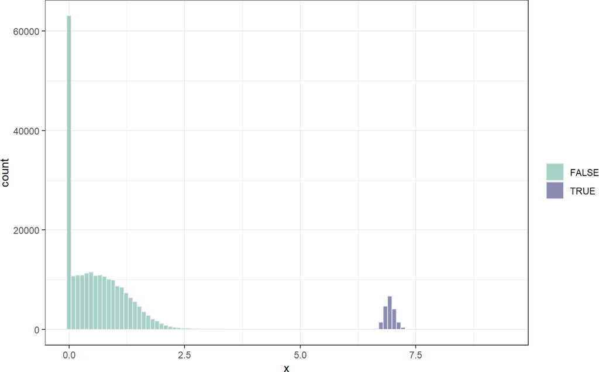

```r
cytofHist(x = tech[, "Bead1"], group = beads$init, "Bead channel")
```

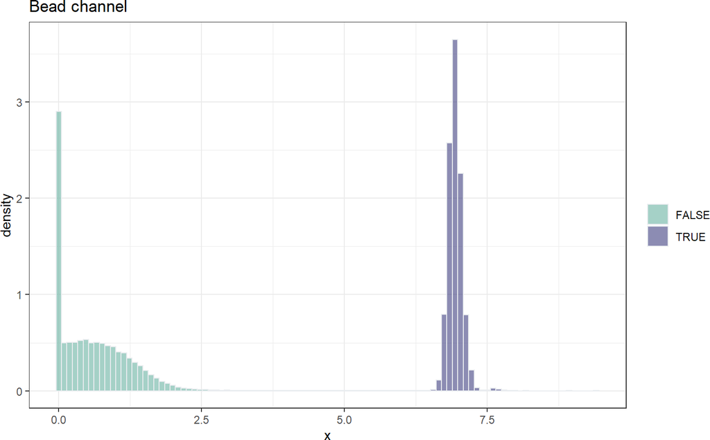

```r
cytofHist(x = tech[, "Bead1"], group = beads$init, type = "density",
          title = "Bead channel")
```

## 4.2 Find mismatches

This next part identifies the observations that are mismatched from its neighbors in regard to bead assignment using the nearest neighbors matrix. If an observation is a designated as a bead, its nearest neighbors that are also beads are assigned a value of FALSE. If a neighbor is not a bead, it is given a value of TRUe, indicating that it is a mismatch of the observation. The rows are then summed together and rows with one or more TRUE values are designated as mismatches. The function returns nearest neighbors matrix with values of TRUE/FALSE as values indicating the mismatch status and a variable called *Mismatch* that is TRUE if the observation is a mismatch and FALSE if it is not.

This is a piece that we are not very happy with at this time. It selects only points that are hard to classify, which means that we are building a labeling model only with points that we are not very certain about. We plan to change this soon.

```r
mm <- mismatch(mnn, beads$init, threshold = 1)
head(mm)
```

```
#>     Time   nn1   nn2   nn3   nn4   nn5   nn6   nn7   nn8   nn9  nn10  nn11
#> 1  6.719 FALSE FALSE FALSE FALSE FALSE FALSE FALSE FALSE FALSE FALSE FALSE
#> 2 13.034 FALSE FALSE FALSE FALSE FALSE FALSE FALSE FALSE FALSE FALSE FALSE
#> 3 13.685 FALSE FALSE FALSE FALSE FALSE FALSE FALSE FALSE FALSE FALSE FALSE
#> 4 19.089 FALSE FALSE FALSE FALSE FALSE FALSE FALSE FALSE FALSE FALSE FALSE
#> 5 25.768 FALSE FALSE FALSE FALSE FALSE FALSE FALSE FALSE FALSE FALSE FALSE
#> 6 40.169 FALSE FALSE FALSE FALSE FALSE FALSE FALSE FALSE FALSE FALSE FALSE
#>    nn12  nn13  nn14  nn15  nn16  nn17  nn18  nn19  nn20 Mismatch
#> 1 FALSE FALSE FALSE FALSE FALSE FALSE FALSE FALSE FALSE    FALSE
#> 2 FALSE FALSE FALSE FALSE FALSE FALSE FALSE FALSE FALSE    FALSE
#> 3 FALSE FALSE FALSE FALSE FALSE FALSE FALSE FALSE FALSE    FALSE
#> 4 FALSE FALSE FALSE FALSE FALSE FALSE FALSE FALSE FALSE    FALSE
#> 5 FALSE FALSE FALSE FALSE FALSE FALSE FALSE FALSE FALSE    FALSE
#> 6 FALSE FALSE FALSE FALSE FALSE FALSE FALSE FALSE FALSE    FALSE
```

```r
sum(mm$Mismatch)
```

```
#> [1] 173
```

## 4.3 Create a subset of data to make a model with

```r
ind <- modelData(labels, subset = mm$Mismatch, init = beads$init, n = 4000)
length(ind)
```

```
#> [1] 4000
```

```r
head(ind)
```

```
#> [1] 222297  15874 218330  57951 128446 227994
```

The following histogram shows where the selected points are relative to the rest of the points for each of the bead channels.

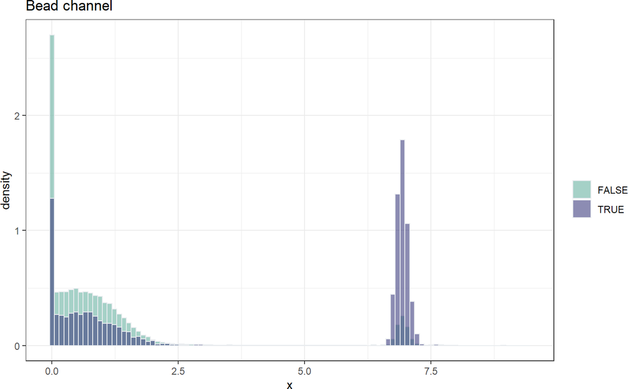

```r
index <- rep(FALSE, nrow(tech))
index[ind] <- TRUE
cytofHist(x = tech[, "Bead1"], group = index, type = "density",
          title = "Bead channel")
```

## 4.4 Final classification of beads

There are currently three models that can be used to classify the beads: support vector machines, random forests, and gradient boosting machines. The method below uses random forests, but the process is identical for SVMs and GBMs. The function for svm and gbm are and . The labeling functions take the same input and produce identical ouput. The output is a that is identical to the but with the beads labeled as beads and the predicted probability of being a bead assigned to each observation in the *bead* variable. This is the *labels* that should be used for the next step because the *bead* label is needed for all other QA labels.

```r
rf.labs <- rfLabel(tech, labels, type = "bead", init = beads$init, index = ind)
head(rf.labs)
```

```
#>     Time label  bead doublet debris dead
#> 1  6.719  cell 0.000      NA     NA   NA
#> 2 13.034  cell 0.000      NA     NA   NA
#> 3 13.685  cell 0.000      NA     NA   NA
#> 4 19.089  cell 0.004      NA     NA   NA
#> 5 25.768  cell 0.000      NA     NA   NA
#> 6 40.169  cell 0.002      NA     NA   NA
```

```r
table(rf.labs$label)
```

```
#>
#>    bead    cell GDPzero
#>   19338  215847   12428
```

These are the plots with the zeros removed

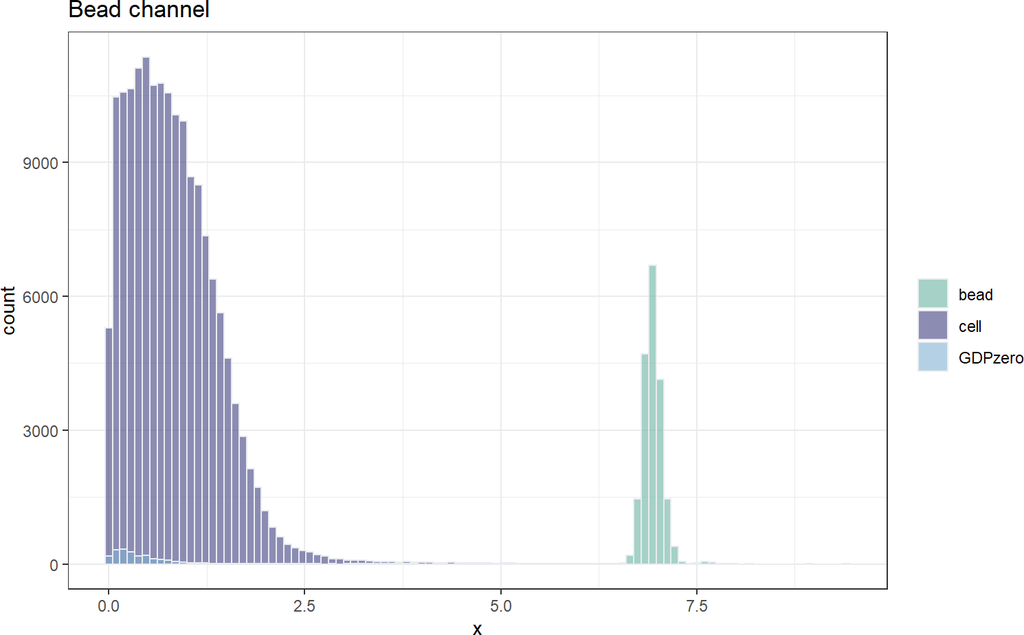

```r
tmp <- data.frame(bead = tech[, "Bead1"], group = rf.labs$label)
tmp <- tmp[tmp$bead > 0, ]
cytofHist(tmp$bead, group = tmp$group, type = "count", title = "Bead channel")
```

# 5 Doublets

This bit labels the doublets. It has the exact same structure as the beads. Note that the updated label should be used because the bead labels are needed for each of the steps.

## 5.1 Initial doublet labeling

The doublets are difficult to classify and we compute a doubletScore to classify them. There are currently three options for classifying the doublet. They are selected using the score argument and they are documented in the help file for . The function returns the doublet score, the group it was assigned to, and the initial doublet classification in the *init* variable.

```r
doublets <- initialDoublet(tech, rf.labs, score = 1)
```

```
#> [1] "removing 1"
#> [1] "removing 2"
```

```r
head(doublets)
```

```
#>     Time doubletScore doubletGroup  init
#> 1  6.719   0.81483725            1 FALSE
#> 2 13.034   0.87867355            1 FALSE
#> 3 13.685   0.09095377            1 FALSE
#> 4 19.089   1.25380547            1 FALSE
#> 5 25.768   0.14394249            1 FALSE
#> 6 40.169  -0.27694356            1 FALSE
```

This shows a classification of the doublet scores for the unclassified points (all of those still labeled *cell*). The scores for the classified points can be seen on the histogram by selection .

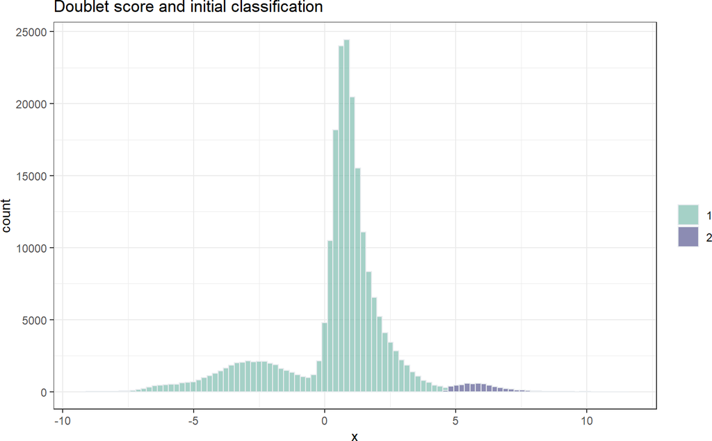

```r
cytofHist(doublets$doubletScore, doublets$doubletGroup, na.rm = TRUE,
          title = "Doublet score and initial classification")
```

## 5.2 Find mismatches

This next part identifies the observations that are mismatched from its neighbors in regard to doublet assignment using the nearest neighbors matrix.

```r
dm <- mismatch(mnn, doublets$init, threshold = 1)
head(dm)
```

```
#>     Time   nn1   nn2   nn3   nn4   nn5   nn6   nn7   nn8   nn9  nn10  nn11
#> 1  6.719 FALSE FALSE FALSE FALSE FALSE FALSE FALSE FALSE FALSE FALSE FALSE
#> 2 13.034 FALSE FALSE FALSE FALSE FALSE FALSE FALSE FALSE FALSE FALSE FALSE
#> 3 13.685 FALSE FALSE FALSE FALSE FALSE FALSE FALSE FALSE FALSE FALSE FALSE
#> 4 19.089 FALSE FALSE FALSE FALSE FALSE FALSE FALSE FALSE FALSE FALSE FALSE
#> 5 25.768 FALSE FALSE FALSE FALSE FALSE FALSE FALSE FALSE FALSE FALSE FALSE
#> 6 40.169 FALSE FALSE FALSE FALSE FALSE FALSE FALSE FALSE FALSE FALSE FALSE
#>    nn12  nn13  nn14  nn15  nn16  nn17  nn18  nn19  nn20 Mismatch
#> 1 FALSE FALSE FALSE FALSE FALSE FALSE FALSE FALSE FALSE    FALSE
#> 2 FALSE FALSE FALSE FALSE FALSE FALSE FALSE FALSE FALSE    FALSE
#> 3 FALSE FALSE FALSE FALSE FALSE FALSE FALSE FALSE FALSE    FALSE
#> 4 FALSE FALSE FALSE FALSE FALSE FALSE FALSE FALSE FALSE    FALSE
#> 5 FALSE FALSE FALSE FALSE FALSE FALSE FALSE FALSE FALSE    FALSE
#> 6 FALSE FALSE FALSE FALSE FALSE FALSE FALSE FALSE FALSE    FALSE
```

```r
sum(dm$Mismatch)
```

```
#> [1] 1894
```

```r
mmPlots <- NULL
mmPlots[[1]] <- cytofHist(doublets$doubletScore, dm$Mismatch, type = "count",
          title = "Mismatched doublets")
mmPlots[[2]] <- cytofHist(doublets$doubletScore, dm$Mismatch, type = "density",
          title = "Mismatched doublets")
```

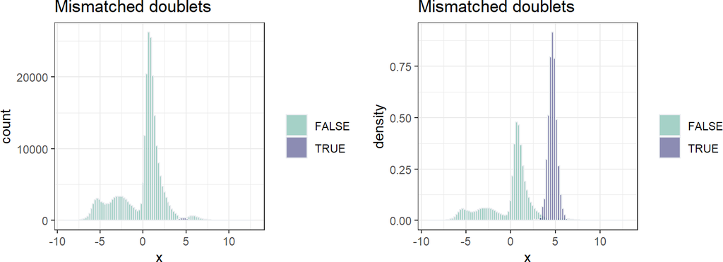

```r
ggpubr::ggarrange(plotlist = mmPlots, ncol = 2, nrow = 1)
```

## 5.3 Create a subset of data to make a model with

The doublets have enough mismatches to draw from to select a dataset from the mismatches.

```r
d.rf.index <- modelData(rf.labs, subset = dm$Mismatch, init = doublets$init, n = 4000)
```

The following histogram shows where the selected points are relative to the rest of the doublet scores.

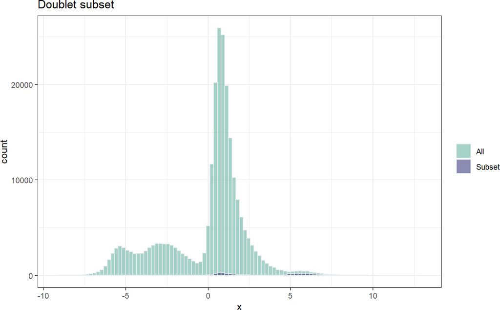

```r
index <- rep("All", nrow(tech))
index[d.rf.index] <- "Subset"
cytofHist(x = doublets$doubletScore, group = index, type = "count",
          title = "Doublet subset")
```

## 5.4 Final classification of doublets

This shows the classification with random forests. Note that the label dataset from the last round of classifying is used as an input and the results are assigned to the same object.

```r
rf.labs <- rfLabel(tech, rf.labs, type = "doublet", init = doublets$init, index = d.rf.index)
head(rf.labs)
```

```
#>     Time label  bead doublet debris dead
#> 1  6.719  cell 0.000       0     NA   NA
#> 2 13.034  cell 0.000       0     NA   NA
#> 3 13.685  cell 0.000       0     NA   NA
#> 4 19.089  cell 0.004       0     NA   NA
#> 5 25.768  cell 0.000       0     NA   NA
#> 6 40.169  cell 0.002       0     NA   NA
```

```r
table(rf.labs$label)
```

```
#>
#>    bead    cell doublet GDPzero
#>   19338  208715    7132   12428
```

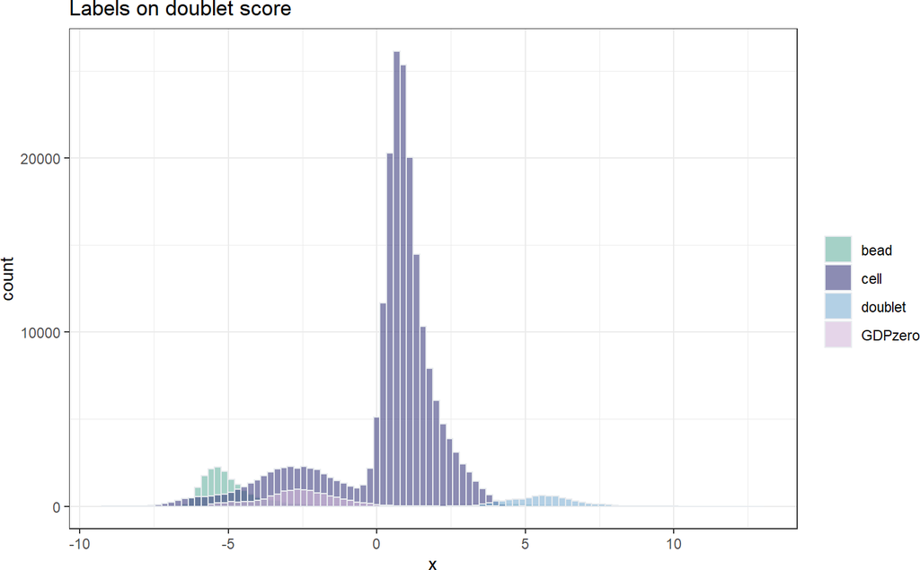

```r
cytofHist(doublets$doubletScore, rf.labs$label, type = "count",
          title = "Labels on doublet score")
```

# 6 Debris

This bit labels the debris. It has the exact same structure as the beads. Note that the updated label should be used because the previous labels are needed for this step.

## 6.1 Initial debris labeling

The debris are difficult to classify and we compute a debrisScore to classify them. There are currently three options for classifying debris. They are selected using the score argument and they are documented in the help file for . The function returns the debris score, the group it was assigned to, and the initial debris classification in the *init* variable.

```r
debris <- initialDebris(tech, rf.labs, score = 1)
head(debris)
```

```
#>     Time debrisScore debrisGroup  init
#> 1  6.719  -1.3053354           1 FALSE
#> 2 13.034  -1.8832501           1 FALSE
#> 3 13.685  -0.5233265           1 FALSE
#> 4 19.089  -1.2416534           1 FALSE
#> 5 25.768  -0.7528685           1 FALSE
#> 6 40.169  -0.8312859           1 FALSE
```

This shows a classification of the debris scores for the unclassified points (all of those still labeled *cell*). The scores for the classified points can be seen on the histogram by selection .

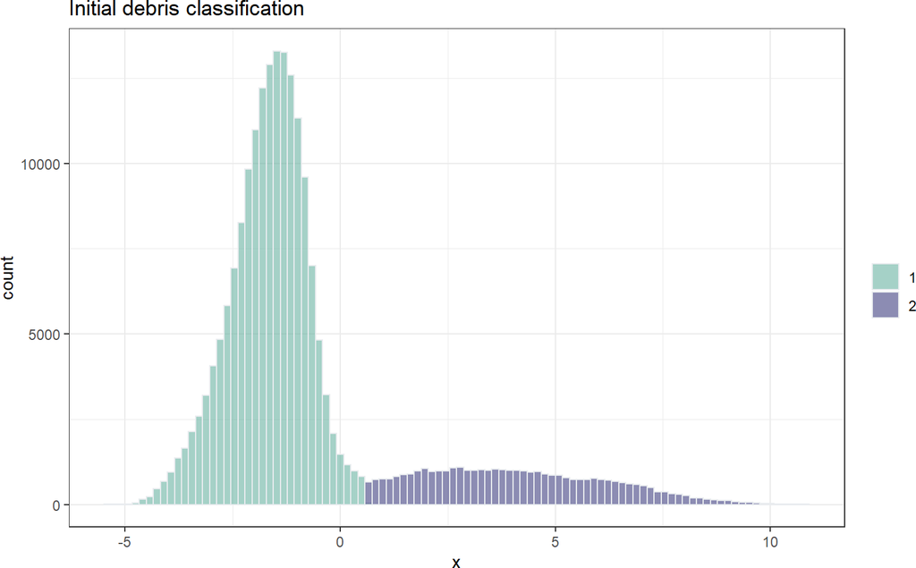

```r
cytofHist(debris$debrisScore, debris$debrisGroup, na.rm = TRUE,
          title = "Initial debris classification")
```

## 6.2 Find mismatches

This next part identifies the observations that are mismatched from its neighbors in regard to debris assignment using the nearest neighbors matrix.

```r
debm <- mismatch(mnn, debris$init, threshold = 1)
head(debm)
```

```
#>     Time   nn1   nn2   nn3   nn4   nn5   nn6   nn7   nn8   nn9  nn10  nn11
#> 1  6.719 FALSE FALSE FALSE FALSE FALSE FALSE FALSE FALSE FALSE FALSE FALSE
#> 2 13.034 FALSE FALSE FALSE FALSE FALSE FALSE FALSE FALSE FALSE FALSE FALSE
#> 3 13.685 FALSE FALSE FALSE FALSE FALSE FALSE FALSE FALSE FALSE FALSE FALSE
#> 4 19.089 FALSE FALSE FALSE FALSE FALSE FALSE FALSE FALSE FALSE FALSE FALSE
#> 5 25.768 FALSE FALSE FALSE FALSE FALSE FALSE FALSE FALSE FALSE FALSE FALSE
#> 6 40.169 FALSE FALSE FALSE FALSE FALSE FALSE FALSE FALSE FALSE FALSE FALSE
#>    nn12  nn13  nn14  nn15  nn16  nn17  nn18  nn19  nn20 Mismatch
#> 1 FALSE FALSE FALSE FALSE FALSE FALSE FALSE FALSE FALSE    FALSE
#> 2 FALSE FALSE FALSE FALSE FALSE FALSE FALSE FALSE FALSE    FALSE
#> 3 FALSE FALSE FALSE FALSE FALSE FALSE FALSE FALSE FALSE    FALSE
#> 4 FALSE FALSE FALSE FALSE FALSE FALSE FALSE FALSE FALSE    FALSE
#> 5 FALSE FALSE FALSE FALSE FALSE FALSE FALSE FALSE FALSE    FALSE
#> 6 FALSE FALSE FALSE FALSE FALSE FALSE FALSE FALSE FALSE    FALSE
```

```r
sum(debm$Mismatch)
```

```
#> [1] 3816
```

```r
mmPlots <- NULL
mmPlots[[1]] <- cytofHist(debris$debrisScore, debm$Mismatch, type = "count",
          title = "Mismatched debris")
mmPlots[[2]] <- cytofHist(debris$debrisScore, debm$Mismatch, type = "density",
          title = "Mismatched debris")
```

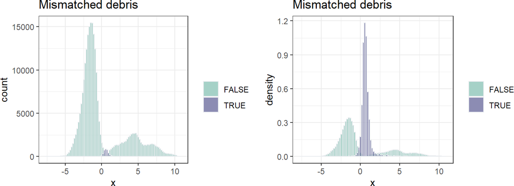

```r
ggpubr::ggarrange(plotlist = mmPlots, ncol = 2, nrow = 1)
```

## 6.3 Create a subset of data to make a model with

The debris have enough mismatches to draw from to select a dataset from the mismatches.

```r
de.rf.index <- modelData(rf.labs, subset = debm$Mismatch, init = debris$init, n = 4000)
```

The following histogram shows where the selected points are relative to the rest of the debris scores.

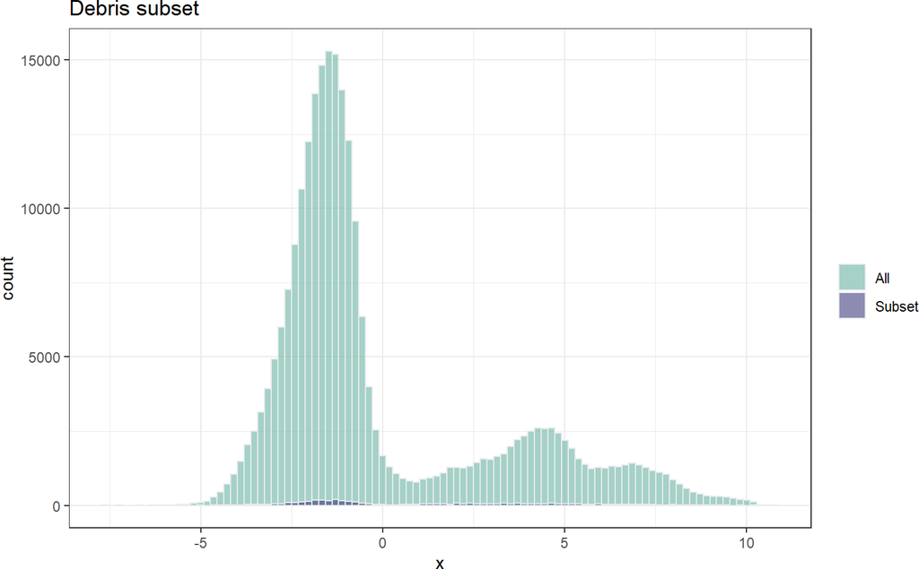

```r
index <- rep("All", nrow(tech))
index[de.rf.index] <- "Subset"
cytofHist(x = debris$debrisScore, group = index, type = "count",
          title = "Debris subset")
```

## 6.4 Final classification of debris

This shows the classification with random forests. Note that the label dataset from the last round of classifying is used as an input and the results are assigned to the same object.

```r
rf.labs <- rfLabel(tech, rf.labs, type = "debris", init = debris$init, index = de.rf.index)
head(rf.labs)
```

```
#>     Time label  bead doublet debris dead
#> 1  6.719  cell 0.000       0  0.000   NA
#> 2 13.034  cell 0.000       0  0.000   NA
#> 3 13.685  cell 0.000       0  0.002   NA
#> 4 19.089  cell 0.004       0  0.000   NA
#> 5 25.768  cell 0.000       0  0.002   NA
#> 6 40.169  cell 0.002       0  0.016   NA
```

```r
table(rf.labs$label)
```

```
#>
#>    bead    cell  debris doublet GDPzero
#>   19338  169893   38822    7132   12428
```

These are the plots of the current labels on the debris score

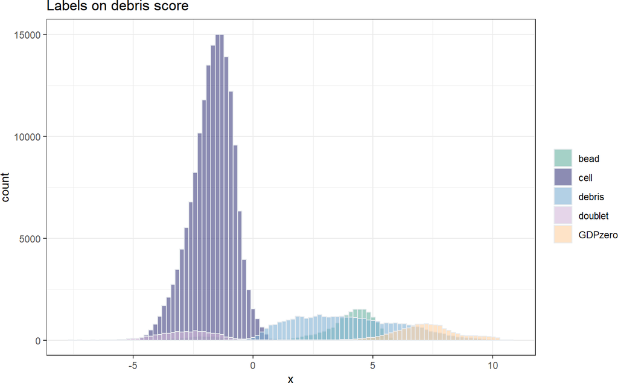

```r
cytofHist(debris$debrisScore, rf.labs$label, type = "count",
          title = "Labels on debris score")
```

# 7 Final summary

The following shows the final labels on the different metrics used to classify.

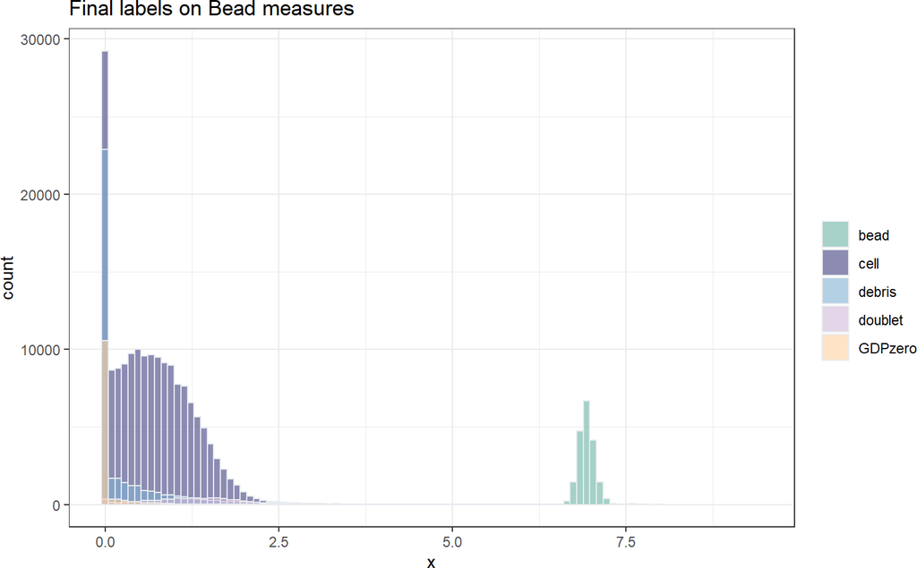

```r
cytofHist(tech[, "Bead1"], rf.labs$label, title = "Final labels on Bead measures")
```

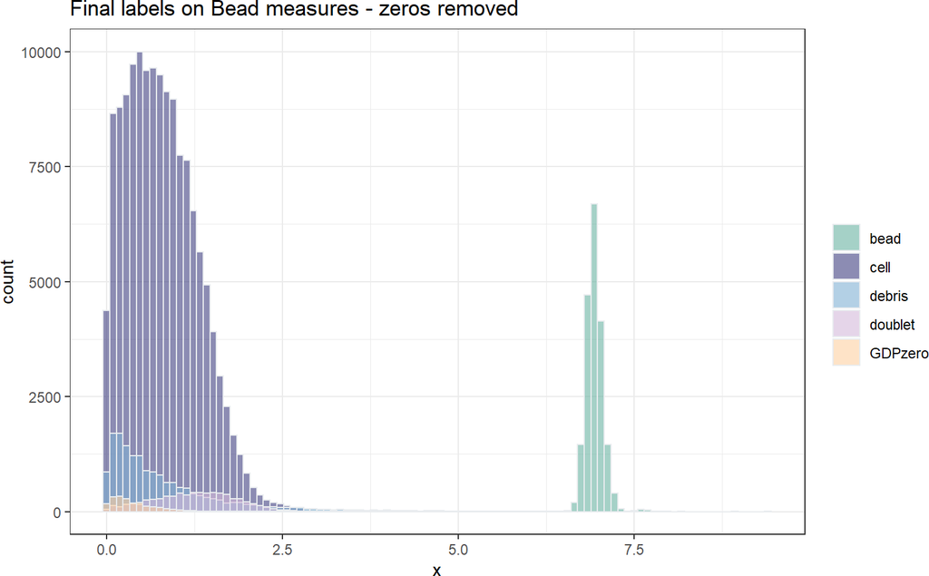

```r
tmp <- data.frame(bead = tech[, "Bead1"], group = rf.labs$label)
tmp <- tmp[tmp$bead > 0, ]
cytofHist(tmp$bead, tmp$group, title = "Final labels on Bead measures - zeros removed")
```

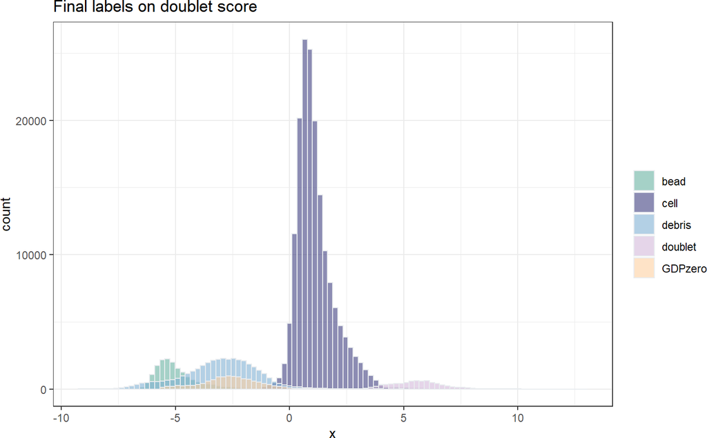

```r
cytofHist(doublets$doubletScore, rf.labs$label, title = "Final labels on doublet score")
```

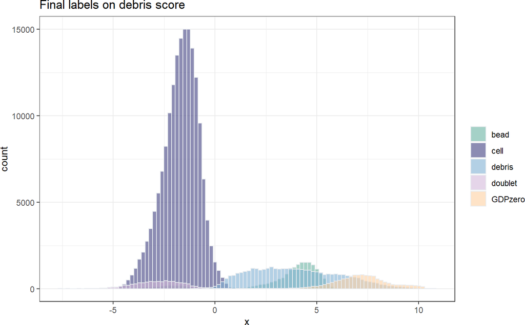

```r
cytofHist(debris$debrisScore, rf.labs$label, title = "Final labels on debris score")
```

This is a umap of the different labels. the umap was created using the standardized *tech* data.

```r
s.tech <- scale(tech[, -1])
lab.umap <- uwot::umap(s.tech, ret_model = TRUE)
lab.umapD <- data.frame(x = lab.umap$embedding[, 1], y = lab.umap$embedding[, 2])
```

```r
g.dat <- CATALYST::prepData(fname)
gfp <- g.dat@assays@data$exprs[rownames(g.dat@assays@data$exprs) == "GFP", ]
vericells <- g.dat@assays@data$exprs[rownames(g.dat@assays@data$exprs) == "VeriCells", ]


umapData <- data.frame(lab.umapD, labels = rf.labs$label)
umapData$bead <- ifelse(rf.labs$label == "bead", "Bead", "Not-Bead")
umapData$doublet <- ifelse(rf.labs$label == "doublet", "Doublet", "Not-Doublet")
umapData$debris <- ifelse(rf.labs$label == "debris", "Debris", "Not-Debris")
umapData$GDPzero <- ifelse(rf.labs$label == "GDPzero", "GDPzero", "Not-GDPzero")
umapData$cell <- ifelse(rf.labs$label == "cell", "Cells", "Not-Cells")
umapData$gfp <- log(gfp)
umapData$vericells <- vericells

umapData$labels <- factor(umapData$labels, levels = c("cell", "GDPzero", "bead", "doublet", "debris"))
```

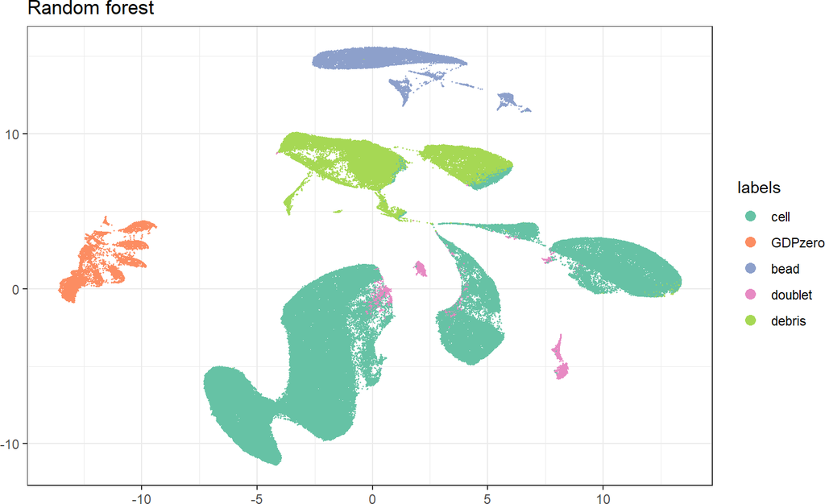

```r
require(RColorBrewer)
cols <- brewer.pal(5, "Set2")
umapG <- ggplot(umapData, aes(x = x, y = y, color = labels)) +
  geom_point(size = 0.25) +
  scale_color_manual(values = cols) +
  labs(title = "Random forest", x = "", y = "") +
  guides(colour = guide_legend(override.aes = list(size = 3))) +
  theme_bw()

umapG
```

Split out by cell type

```r
umaps <- NULL
cell_type <- levels(umapData$labels)

for (i in 1:5) {
  tmp <- data.frame(umapData[, 1:2], lab = umapData[, cell_type[i]])
  umaps[[i]] <- ggplot(tmp, aes(x = x, y = y, color = lab)) +
    geom_point(size = 0.25, show.legend = FALSE) +
    scale_color_manual("", values = c(cols[i], "gray70")) +
    labs(title = cell_type[i], x = "", y = "") +
    theme_bw()
}
```

```r
umaps[[6]] <- ggplot(umapData, aes(x = x, y = y, color = gfp)) +
    geom_point(size = 0.5, show.legend = FALSE) +
    scale_colour_gradient(low = "#56B1F7", high = "#132B43", space = "Lab",
                          na.value = "white", guide = "colourbar",
                          aesthetics = "colour") +
    # scale_color_continuous("", type = "gradient", values = "reds") +
    labs(title = "GFP", x = "", y = "") +
    theme_bw()
```

```r
umaps[[7]] <- ggplot(umapData, aes(x = x, y = y, color = vericells)) +
    geom_point(size = 0.5, show.legend = FALSE) +
    scale_colour_gradient(low = "#f6eff7", high = "#016450", space = "Lab",
                          na.value = "white", guide = "colourbar",
                          aesthetics = "colour") +
    # scale_color_continuous("", type = "gradient", values = "reds") +
    labs(title = "Vericells", x = "", y = "") +
    theme_bw()
```

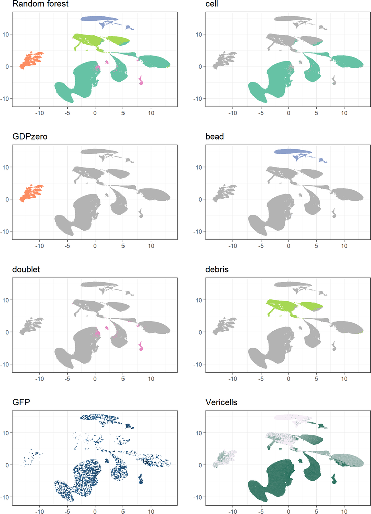

```r
library(gridExtra)
grid.arrange(umapG + guides(col = "none"), umaps[[1]], umaps[[2]],
             umaps[[3]], umaps[[4]], umaps[[5]], umaps[[6]],
             umaps[[7]], nrow = 4, ncol = 2)
```